# Seawater Hydro Station Lab

Juanita Carballeira

March 23, 2023

## 1. Pick a question and include hypothesis

Question: What is the relationship between temperature and salinity at the site? Are these variables a good indicator for stratification and is there seasonal variation?

Hypothesis: Temperature is a driver for salinity, resulting in a density change which will lead to stratified water. Warmer months (summer) will have a greater stratification than colder (winter) months.

## 2. Produce a plot and a statistical summary: lm model

Part 1: Piping data

```r
##Libraries used
library(tidyverse)
#install.packages ("seacarb")
library(seacarb)
```

```r
library(gsw)
library(ggplot2)
##Import data

hydrostation_bottle <- read_delim("hydrostation_bottle.txt",
    delim = "\t", escape_double = FALSE,
    col_names = FALSE, trim_ws = TRUE, skip = 31)
hydrostation_bottle_names <- read_csv("hydrostation_bottle.txt",
    skip = 30)
colnames(hydrostation_bottle) = colnames(hydrostation_bottle_names)
view(hydrostation_bottle)
```

```r
hydrostation_bottle =  hydrostation_bottle %>%
  mutate(Pres_gsw = gsw_p_from_z(Depth*-1, latN)) %>%
  mutate(s_abs_gsw = gsw_SA_from_SP(Sal1, Pres_gsw,360-lonW, latN))


HydroS =  hydrostation_bottle %>%
  filter(Sal1 != -999 & `Sig-th` != -999) %>%
  mutate(Pres_gsw = gsw_p_from_z(Depth*-1, latN)) %>%
  mutate(s_abs_gsw = gsw_SA_from_SP(Sal1, Pres_gsw,360-lonW, latN)) %>%
  mutate(T_Cons_gsw = gsw_CT_from_t(s_abs_gsw,Temp,Pres_gsw)) %>%
  mutate(sig_theta_gsw = gsw_sigma0(s_abs_gsw,T_Cons_gsw))
```

```r
HydroS_Corrected_a = HydroS %>%
  filter(sig_theta_gsw<0) %>%
  mutate(s_abs_gsw = gsw_SA_from_SP(CTD_S, Pres_gsw,360-lonW, latN)) %>%
  mutate(T_Cons_gsw = gsw_CT_from_t(s_abs_gsw,Temp,Pres_gsw)) %>%
  mutate(sig_theta_gsw = gsw_sigma0(s_abs_gsw,T_Cons_gsw))

HydroS_Corrected_b = HydroS %>%
  filter(sig_theta_gsw>0)


HydroS_corrected = rbind(HydroS_Corrected_a,HydroS_Corrected_b)
```

Part 2: Temperature and Salinity plots

```r
#Create season variable for summer and winter
Hydro_seasonal=
HydroS_corrected %>%
mutate(month = substr(yyyymmd,5,6))%>%
mutate(month=as.numeric(substr(yyyymmd,5,6))) %>%
mutate(season =ifelse(month==12|month==1|month==2|month==3,'winter',ifelse(month==8|month==9|month==10,'summer',''))) # adds seasons to data
View(Hydro_seasonal)
```

```r
#Visualize winter and summer data

Winter_data=
Hydro_seasonal %>%
  filter(Sal1>1.150) %>%
  filter(season=="winter")
#View(Winter_data)
max(Winter_data$Sal1,na.rm=TRUE)
```

```
## [1] 36.859
```

```r
min(Winter_data$Sal1,na.rm=TRUE)
```

```
## [1] 34.55
```

```r
max(Winter_data$T_Cons_gsw,na.rm=TRUE)
```

```
## [1] 24.00017
```

```r
min(Winter_data$T_Cons_gsw,na.rm=TRUE)
```

```
## [1] 1.820868
```

```r
Summer_data=
Hydro_seasonal %>%
  filter(Sal1>1.150) %>%
  filter(season=="summer")
#View(Summer_data)
max(Summer_data$Sal1,na.rm=TRUE)
```

```
## [1] 37.038
```

```r
min(Summer_data$Sal1,na.rm=TRUE)
```

```
## [1] 33.431
```

```r
max(Summer_data$T_Cons_gsw,na.rm=TRUE)
```

```
## [1] 29.48312
```

```r
min(Summer_data$T_Cons_gsw,na.rm=TRUE)
```

```
## [1] 1.941886
```

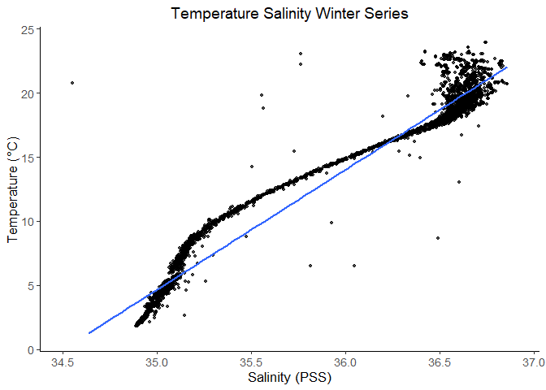

```r
#Plot winter data and generate lm model
TS_winterplot=
 Winter_data%>%
  ggplot()+
  geom_point(aes(x=Sal1,y= T_Cons_gsw),size=1,alpha=0.7)+
  ggtitle("Temperature Salinity Winter Series")+
  xlab('Salinity (PSS)')+
  ylab('Temperature (°C)')+
  scale_x_continuous(limits=c(34.5,36.91))+
  scale_y_continuous(limits=c(1,24.00017))+
  theme(panel.grid.major = element_blank(),
        panel.grid.minor = element_blank(),
        panel.background = element_blank(),
        axis.line = element_line(color="black"),
        plot.title=element_text(hjust=.5,size=14),
        text = element_text(size=13))+
  geom_smooth(aes(x=Sal1, y=T_Cons_gsw),method = "lm")
TS_winterplot
```

```r
TS_winterplotlm = lm(T_Cons_gsw~Sal1,data =  Winter_data)
summary(TS_winterplotlm)
```

```
##
## Call:
## lm(formula = T_Cons_gsw ~ Sal1, data = Winter_data)
##
## Residuals:
##     Min      1Q  Median      3Q     Max
## -9.9738 -0.9900 -0.4550  0.8411 20.3312
##
## Coefficients:
##               Estimate Std. Error t value Pr(>|t|)
## (Intercept) -323.19026    0.99893  -323.5   <2e-16 ***
## Sal1           9.36719    0.02779   337.0   <2e-16 ***
## ---
## Signif. codes:  0 '***' 0.001 '**' 0.01 '*' 0.05 '.' 0.1 ' ' 1
##
## Residual standard error: 1.377 on 4549 degrees of freedom
## Multiple R-squared:  0.9615, Adjusted R-squared:  0.9615
## F-statistic: 1.136e+05 on 1 and 4549 DF,  p-value: < 2.2e-16
```

```r
TS_winterplotlm
```

```
##
## Call:
## lm(formula = T_Cons_gsw ~ Sal1, data = Winter_data)
##
## Coefficients:
## (Intercept)         Sal1
##    -323.190        9.367
```

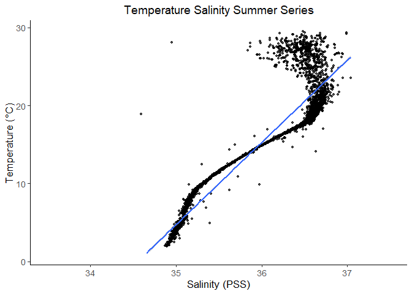

```r
#Plot summer data and generate lm model
TS_summerplot=
 Summer_data%>%
  ggplot()+
  geom_point(aes(x=Sal1,y=T_Cons_gsw),size=1,alpha=0.7)+
  ggtitle("Temperature Salinity Summer Series")+
  xlab('Salinity (PSS)')+
  ylab('Temperature (°C)')+
  scale_x_continuous(limits=c(33.5,37.5))+
  scale_y_continuous(limits=c(1,29.5))+
  theme(panel.grid.major = element_blank(),
        panel.grid.minor = element_blank(),
        panel.background = element_blank(),
        axis.line = element_line(color="black"),
        plot.title=element_text(hjust=.5,size=14),
        text = element_text(size=13))+
  geom_smooth(aes(x=Sal1, y=T_Cons_gsw),method = "lm")
TS_summerplot
```

```r
TS_summerplotlm = lm(T_Cons_gsw~Sal1,data =  Summer_data)
summary(TS_summerplotlm)
```

```
##
## Call:
## lm(formula = T_Cons_gsw ~ Sal1, data = Summer_data)
##
## Residuals:
##     Min      1Q  Median      3Q     Max
## -7.8191 -2.2896 -0.8881  1.2275 23.8259
##
## Coefficients:
##               Estimate Std. Error t value Pr(>|t|)
## (Intercept) -364.31964    2.41387  -150.9   <2e-16 ***
## Sal1          10.54461    0.06722   156.9   <2e-16 ***
## ---
## Signif. codes:  0 '***' 0.001 '**' 0.01 '*' 0.05 '.' 0.1 ' ' 1
##
## Residual standard error: 3.164 on 4213 degrees of freedom
## Multiple R-squared:  0.8538, Adjusted R-squared:  0.8538
## F-statistic: 2.46e+04 on 1 and 4213 DF,  p-value: < 2.2e-16
```

```r
TS_summerplotlm
```

```
##
## Call:
## lm(formula = T_Cons_gsw ~ Sal1, data = Summer_data)
##
## Coefficients:
## (Intercept)         Sal1
##     -364.32        10.54
```

## 3. Describe your results, the summary, and answer the question

Temperature and Salinity Winter series linear regression: Winter series data showed a good linearity (R2=0.9615), and a slope of 9.37◦C/PSS. Meaning that for every 1 unit of PSS, there is a temperature increase of approximately 9.37◦C.

Temperature and Salinity Summer series linear regression: Summer series data showed an acceptable linearity (R2= 0.8538), and a slope of 10.54◦C/PSS. Meaning that for every 1 unit of PSS, there is a temperature increase of approximately 10.54◦C.

Results Discussion:

Plots for both summer and winter months indicate a strong correlation between temperature and salinity. Overall, temperature increase was characterized by an increase in salinity and vice versa. Data shows a thermocline which marks a transitional layer between different water masses, indicating stratification.

Both plots presented greater salinity variability at higher temperatures, which could be explained by climate processes occurring at the surface layer. When comparing seasons, winter months showed less salinity differences at higher temperatures than summer months. This concurs with our predictions that in the summer months there should be less mixing expected. We can infer from the results that temperature proved to have less variability than salinity, making temperature a better predictor of changes in density.